# Solution for Homework #1

## ELEC/IEDA 3180

## TA: Yifan Yu

# Problem 1

## Question (1)

The objective function is a quadratic term. Provided that the matrix $\boldsymbol{\Sigma}$ is positive semi-definite (PSD), then the objective function is convex. The constraints of the problem are affine. Thus, the problem is convex provided that $\boldsymbol{\Sigma} \succeq \mathbf{0}$.

Here we provide two ways to prove the the matrix $\boldsymbol{\Sigma}$ is positive semi-definite (PSD).

### (i) Prove $\boldsymbol{\Sigma}$ is PSD from definition

For any non-zero column vector $\mathbf{z}$ with entries $a, b, c$, we have \begin{align} \mathbf{z}^\top\boldsymbol{\Sigma}\mathbf{z} &= \begin{bmatrix} a & b & c \end{bmatrix} \begin{bmatrix} 1.0 & -0.003 & 0.02 \\ -0.003 & 1.0 & -0.15 \\ 0.02 & -0.15 & 1.0 \end{bmatrix} \begin{bmatrix} a \\ b \\ c \end{bmatrix} \\ &= a^2 + b^2 + c^2 - 0.006ab + 0.04ac - 0.3bc \\ &= 0.977a^2 + 0.847b^2 + 0.83c^2 + 0.003(a-b)^2 + 0.02(a+c)^2 + 0.15(b-c)^2 > 0. \end{align} According to the definition of [positive semi-definite](https://en.wikipedia.org/wiki/Definite_matrix#Definitions_for_real_matrices), it is clear that $\boldsymbol{\Sigma}$ is PSD.

### (ii) Prove $\boldsymbol{\Sigma}$ is PSD via the definition of covariance matrix.

Since $\boldsymbol{\Sigma}$ is the covariance matrix of the stock returns, another way is to directly prove that a covariance matrix is always a positive-semidefinite matrix. Suppose the stock returns is $\mathbf{X}$, the covariance matrix of the stock returns is equivalent to $$ \boldsymbol\Sigma = \mathbb{E}[(\mathbf{X}-\mathbb{E}[\mathbf{X}])(\mathbf{X}-\mathbb{E}[\mathbf{X}])^\top]. $$ For any non-zero column vector $\mathbf{z}$, we have \begin{align} \mathbf{z}^\top\boldsymbol{\Sigma}\mathbf{z} &= \mathbf{z}^\top\mathbb{E}[(\mathbf{X}-\mathbb{E}[\mathbf{X}])(\mathbf{X}-\mathbb{E}[\mathbf{X}])^\top]\mathbf{z} \\ &= \mathbb{E}[\mathbf{z}^\top(\mathbf{X}-\mathbb{E}[\mathbf{X}])(\mathbf{X}-\mathbb{E}[\mathbf{X}])^\top\mathbf{z}] \\ &= \mathbb{E}[\vert\vert(\mathbf{X}-\mathbb{E}[\mathbf{X}])^\top\mathbf{z}\vert\vert^2] \geq 0. \end{align} Therefore, it is clear that $\boldsymbol{\Sigma}$ is PSD.

## Question (2)

```python
import math
import cvxpy as cp
import numpy as np
import matplotlib.pyplot as plt
import time
plt.style.use('ggplot')
```

```python
Sigma = np.array([[1., -0.003, 0.02], [-0.003, 1., -0.15], [0.02, -0.15, 1.0]])
mu = np.array([0.02, 0.003, 0.07])
beta_vals = np.array([5*10**(-3) * k for k in range(13)])
```

```python
risks = []
returns = []
w_list = []
for beta in beta_vals:
    w = cp.Variable(len(mu))
    variance = cp.quad_form(w, Sigma)
    exp_return = w @ mu
    problem = cp.Problem(cp.Minimize(variance), [exp_return >= beta, w >= 0, cp.sum(w) == 1])
    problem.solve()
    risks.append(math.sqrt(variance.value))
    returns.append(exp_return.value)
    w_list.append(w.value)
```

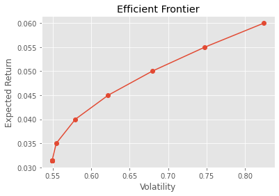

```python
plt.plot(risks, returns, 'o-')
plt.xlabel("Volatility")
plt.ylabel("Expected Return")
plt.title("Efficient Frontier")
plt.show()
```

## Question (3)

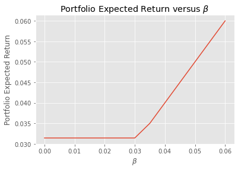

```python
plt.plot(beta_vals, returns)
plt.xlabel("$\\beta$")
plt.ylabel("Portfolio Expected Return")
plt.title("Portfolio Expected Return versus $\\beta$")
plt.show()
```

For $\beta \geq 0.035$. (Due to the computational accuracy，answers like $\beta > 0.03$ and $\beta \geq 0.045$ are regarded as correct ones.)

We would get no feasible point when $\beta>0.07$ since the constraints are inconsistent.

## Question (4)

```python
# Method 1
start_time = time.time()

for beta in beta_vals:
    w = cp.Variable(len(mu))
    variance = cp.quad_form(w, Sigma)
    exp_return = w @ mu
    problem = cp.Problem(cp.Minimize(variance), [exp_return >= beta, w >= 0, cp.sum(w) == 1])
    problem.solve()
    if (beta == 0.01):
        w_1 = w.value


elapsed_time_1 = time.time() - start_time


# Method 2
start_time = time.time()

betas = cp.Parameter(nonneg = True)
w = cp.Variable(len(mu))
variance = cp.quad_form(w, Sigma)
exp_return = w @ mu
problem = cp.Problem(cp.Minimize(variance), [exp_return >= betas, w >= 0, cp.sum(w) == 1])


for beta in beta_vals:
    betas.value = beta
    problem.solve()
    if (beta == 0.01):
        w_2 = w.value

elapsed_time_2 = time.time() - start_time
```

```python
print("Method 1:".center(20, '='))
print("Optimal portfolio (w*) when beta=0.01: {}".format(w_1))
print("Elapsed time after 1 iterations: {:.4f}s \n".format(elapsed_time_1))

print("Method 2:".center(20, '='))
print("Optimal portfolio (w*) when beta=0.01: {}".format(w_2))
print("Elapsed time after 1 iterations: {:.4f}s \n".format(elapsed_time_2))

print("The second method is {:.2f}x faster than the first method.".format(elapsed_time_1 / elapsed_time_2))
```

```
=====Method 1:======
Optimal portfolio (w*) when beta=0.01: [0.29585799 0.35502959 0.34911243]
Elapsed time after 1 iterations: 0.1048s

=====Method 2:======
Optimal portfolio (w*) when beta=0.01: [0.29585799 0.35502959 0.34911243]
Elapsed time after 1 iterations: 0.0382s

The second method is 2.74x faster than the first method.
```

## Question (5)

```python
beta_vals = np.array([5*10**(-3) * k for k in range(1,13)])
```

```python
risks = []
returns = []
w_list = []
for beta in beta_vals:
    w = cp.Variable(len(mu))
    variance = cp.quad_form(w, Sigma)
    exp_return = w @ mu
    problem = cp.Problem(cp.Minimize(variance), [exp_return == beta, w >= 0, cp.sum(w) == 1])
    problem.solve()
    risks.append(math.sqrt(variance.value))
    returns.append(exp_return.value)
    w_list.append(w.value)
```

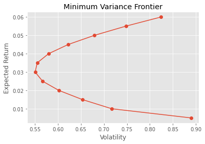

```python
plt.plot(risks, returns, 'o-')
plt.xlabel("Volatility")
plt.ylabel("Expected Return")
plt.title("Minimum Variance Frontier")
plt.show()
```

The frontier in Question (5) contains inefficient points. There are points with higher risk and lower return.

Since $\boldsymbol{\mu}^\top\mathbf{w}$ does not have to be equal to $\beta$ while minimizing the variance in Question (2), higher return can be got with the same level of risk.